# AI Aversion Predictive Model

2025-06-29

## Prediction AI Aversion from 2019 Oxford Internet Survey

It is not feasible to identify AI-averse individuals, without directly asking about their attitudes to this technology based on the 2019 Oxford Internet Survey.

The survey dataset includes a variable, `agai`, representing respondents’ agreement with the statement:

*Artificial Intelligence will bring overall positive benefits for society.*

Responses follow a Likert Scale (1 = Strongly Disagree, 5 = Strongly Agree). Those who selected 1 or 2 are classified as AI Averse, while those who chose 3, 4, 5, or Don’t Know (NA) are Not Averse. The variable was re-coded as binary, with the positive class indicating AI aversion. Other variables are treated as predictors.

Since many predictors use a Likert Scale and have large numbers of missing values, linear models (e.g., LASSO, Ridge) are unsuitable. Additionally, with this data-structure KNN clustering is computationally inefficient. Instead, CART models were chosen because they can handle both categorical and continuous variables, as well as missing values without imputation. Missing values are not random (e.g., “Don’t Know”, “Refused”), so they remain in the dataset. However, they are excluded from the model to avoid assigning an artificial order to them.

Variables that only pertain to the survey methodology have been excluded from my model, as they do not provide information about the preferences of respondents.

In the dataset there are significantly more instances of the negative class, than the positive class. To make sure that there are enough instances of the positive class to validate the model, I used stratified sampling, rather than random sampling.

First, I trained a CART model to understand its baseline performance. Due to the class imbalance in the dataset, Table 1 shows that the model is able to identify people who are not AI averse (negative class). However, it performs significantly worse on the positive class (AI aversion).

Table 1: Model Performance Metrics on Basic CART

| Precision | Recall | F1_Score |
| --- | --- | --- |
| 0.8402367 | 0.9466667 | 0.8902821 |
| 0.3600000 | 0.1428571 | 0.2045455 |

To address class imbalance, various resampling techniques were tested (e.g., class weighting, upsampling, downsampling, bootstrap sampling). While these methods improved recall, they also led to more false positives, keeping precision low.

The model that performed the best with a baseline complexity parameter was fine-tuned at the end to minimize overfitting and maximize model performance.

Among the tested models, the one with the highest F1 score was selected, as it balances precision and recall. Given the high class imbalance, overall accuracy was not a reliable metric, as a model predicting all observations as the majority class could still achieve a high accuracy.

Since the goal is to predict AI aversion, model evaluation only focused on metrics relative to the positive class. A model that increases recall but decreases precision without improving the relationship between predictors and the response variable is not truly effective. Similarly, a model that improves precision at the cost of recall may fail to capture enough instances of AI aversion. Therefore, F1 score, which balances precision and recall, served as the best measure of model performance.

The best performing model used bootstrap sampling that upsampled the positive class. To tune the model, cross-validation was used to find the best complexity parameter for each k-bootstrap; these values were then averaged to determine the optimal hyperparameter. Each observation was classified using a threshold that maximized the ROC-AUC. The model was then retrained at this optimal threshold and validated on the validation set.

This model was then run on the test data to evaluate out-of-sample performance. To evaluate this, we can look at its metrics on the test data. Table 2 shows that it still has a weak performance on the positive class compared to the negative class.

Table 2: Model Performance Metrics on Test Data

| Class | Precision | Recall | F1_Score |
| --- | --- | --- | --- |
| 0 | 0.8623482 | 0.7100000 | 0.7787934 |
| 1 | 0.2500000 | 0.4603175 | 0.3240223 |

Plotting this sensitivity vs. specificity on the ROC curve you can see that it predicts better than random chance, but not by much.

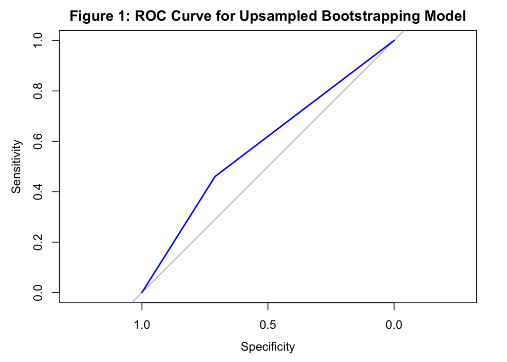

To see what is happening behind the model, the first model from my 20 bootstrapped models can be visualized.

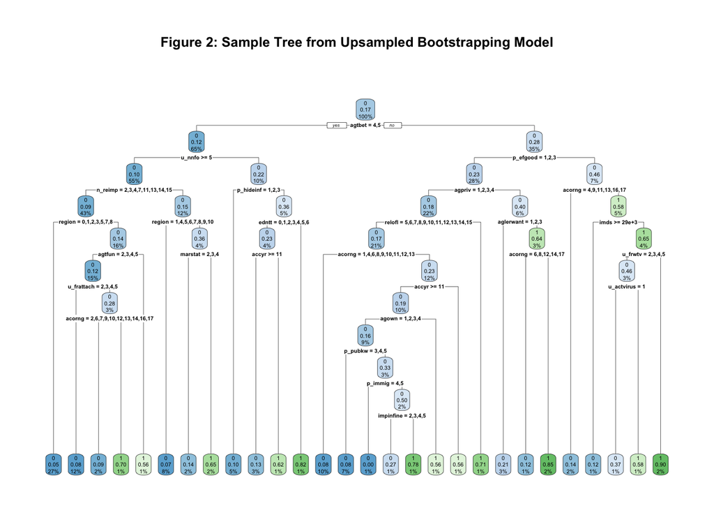

## Appendix: All code in this assignment

```r
# this chunk contains code that sets global options for the entire .Rmd.
# we use include=FALSE to suppress it from the top of the document, but it will still appear in the appendix.

knitr::opts_chunk$set(echo = FALSE) # actually set the global chunk options.
# we set echo=FALSE to suppress code such that it by default does not appear throughout the document.
# note: this is different from .Rmd default
# install and load the haven package if necessary
if (!requireNamespace("haven", quietly = TRUE)) install.packages("haven")
if (!requireNamespace("glmnet", quietly = TRUE)) install.packages("glmnet")
if (!requireNamespace("tidyverse", quietly = TRUE)) install.packages("tidyverse")
if (!requireNamespace("rpart", quietly = TRUE)) install.packages("rpart")
if (!requireNamespace("rpart.plot", quietly = TRUE)) install.packages("rpart.plot")
if (!requireNamespace("caret", quietly = TRUE)) install.packages("caret")
if (!requireNamespace("pROC", quietly = TRUE)) install.packages("pROC")
if (!requireNamespace("knitr", quietly = TRUE)) {install.packages("knitr")}
if (!requireNamespace("flextable", quietly = TRUE)) {install.packages("flextable")}

# Load the packages
library(knitr)
library(kableExtra)
library(haven)
library(glmnet)
library(tidyverse)
library(rpart)
library(rpart.plot)
library(caret)
library(pROC)
library(flextable)
# Load the data
internet_data <- read_dta("/Users/Cora/Documents/MY474/UKDA-9146-stata/stata/stata14/oxis2019ukda.dta")

# Convert internet_data to a dataframe in the format in which it was originally loaded into workspace
internet_df <- as.data.frame(internet_data)

# now using the original, haven labelled data, mutate across columns renaming cols their labels
internet_data <- internet_data %>%
  mutate(across(where(is.labelled), ~ as_factor(.)))

#  Function to check if "No" exists in the values of the column, these are present in the binary cols
check_no_in_column <- function(col) {
  if ("No" %in% col) {
    return(TRUE)
  }
  return(FALSE)
}

# Loop through each column in internet_data and check for "No"
binary_search <- names(internet_data)[sapply(internet_data, function(col) {
  # Convert to character if it's a labeled numeric vector
  col_vals <- if (inherits(col, "labelled")) {
    labels <- attr(col, "labels")
    factor(col, levels = labels)
  } else {
    col
  }

  # Check if "No" is in the column values
  check_no_in_column(col_vals)
})]

# Loop through the data-frame converted data and look for where all NA cols are either only 0 or 1
binary_cols <- names(internet_df)[sapply(internet_df, function(col) {
  if (is.numeric(col)) {
    all(na.omit(col) %in% c(0, 1))  # Only check non-NA values
  } else {
    FALSE  # Exclude non-numeric columns
  }
})]


# find unordered factor cols
factor_cols <- c("s_wheng", "acornc", "acorng", "u_fund", "u_lerloc", "p_party", "labfor","marstat", "urbrur", "region", "u_lerloc", "u_gofir", "n_reimp", "e_reimpu", "e_reimps", "e_renotuse", "cs_bank", "cs_form", "cs_vid", "cs_pjt", "cs_heal", "eth4")

# find cols used for survey methods to remove
survey_cols <- c("doi", "intid", "oap", "agew", "acornt", "visits", "oadist", "serial", "weight")

# numeric cols
cont_cols <- c("accyr", "nbad", "ngovf", "ngovfo", "ngovo", "ngovoo","nhh", "nicts", "nindev", "nmob", "popul5", "u_ncom", "u_nent", "u_nlea","u_nnfo", "u_npdn", "u_nsns", "u_nsnsact", "yonline", "lernsc", "lonely", "p_ef", "popul", "stpriv", "techatt", "u_ncom", "age","e_stopyr","e_usedyr", "usedyr", "yrborn", "adulthh", "imds")

# now the rest should be ordered factors
selected_cols <- c(binary_cols, factor_cols, survey_cols, cont_cols, binary_search)
orderd_cols <- setdiff(names(internet_df), selected_cols)

# convert ordered cols to ordered factor variables
internet_df[orderd_cols] <- lapply(internet_df[orderd_cols],
                                        function(x) factor(x, ordered = TRUE))

# convert numeric cols to numeric
for (col in cont_cols) {
  if (col %in% names(internet_df)) {
    internet_df[[col]] <- as.numeric(internet_df[[col]])
  }
}

# convert unordered factor columns to factors
for (col in factor_cols) {
  if (col %in% names(internet_df)) {
    internet_df[[col]] <- as.factor(internet_df[[col]])
  }
}

# convert binary cols to factors
for (col in binary_cols) {
  if (col %in% colnames(internet_df)) {
    internet_df[[col]] <- as.factor(internet_df[[col]])
  }
}

# convert binary columns to factors, ensuring all expected levels are present
for (col in binary_search) {
  if (col %in% colnames(internet_df)) {
    internet_df[[col]] <- as.factor(internet_df[[col]])
  }
}

# remove survey columns
internet_df <- internet_df[ , !(names(internet_df) %in% survey_cols)]

# Recode agai: 1 & 2 -> 1, 3, 4, 5, NA -> 0
binary_df <- internet_df
binary_df$agai <- ifelse(is.na(binary_df$agai) | binary_df$agai %in% c(3, 4, 5), 0, 1)
binary_df$agai <- as.factor(binary_df$agai)  # Convert to factor

# Set seed for reproducibility
set.seed(123)

# Perform stratified sampling to maintain class balance
train_idx <- createDataPartition(binary_df$agai, p = 0.6, list = FALSE)  # 60% Training
train_data <- binary_df[train_idx, ]
remaining_data <- binary_df[-train_idx, ]

# Split remaining 40% into validation (20%) and test (20%) - stratified
valid_idx <- createDataPartition(remaining_data$agai, p = 0.5, list = FALSE)  # 50% of remaining
valid_data <- remaining_data[valid_idx, ]
test_data <- remaining_data[-valid_idx, ]

# Separate response variable
train_X <- train_data
valid_X <- valid_data
test_X <- test_data

train_y <- train_X$agai
valid_y <- valid_X$agai
test_y <- test_X$agai

# Remove response variable from predictor datasets
train_X$agai <- NULL
valid_X$agai <- NULL
test_X$agai <- NULL

# Define function to evaluate model performance later
calc_metrics <- function(conf_matrix) {
  num_classes <- nrow(conf_matrix)  # Number of classes
  metrics_df <- data.frame(Precision = numeric(num_classes),
                           Recall = numeric(num_classes),
                           F1_Score = numeric(num_classes),
                           row.names = rownames(conf_matrix))  # Maintain class labels
```

```r
  for (i in 1:num_classes) {
    tp <- conf_matrix[i, i]  # True Positives
    fp <- sum(conf_matrix[i, ]) - tp  # False Positives
    fn <- sum(conf_matrix[, i]) - tp  # False Negatives
    tn <- sum(conf_matrix) - tp - fp - fn  # True Negatives

    precision <- ifelse(tp + fp > 0, tp / (tp + fp), 0)
    recall <- ifelse(tp + fn > 0, tp / (tp + fn), 0)
    f1_score <- ifelse((precision + recall) > 0, 2 * (precision * recall) / (precision + recall), 0)

    # Store results in dataframe
    metrics_df$Precision[i] <- precision
    metrics_df$Recall[i] <- recall
    metrics_df$F1_Score[i] <- f1_score
  }

  return(metrics_df)
}

# Basic Binary Classification Tree
tree <- rpart(train_y ~ .,
                    data = train_X,
                    method = "class")

# Define a function to find the complexity parameter (cp) with the best xerror
find_best_cp <- function(tree_model) {

  # Extract cp table
  cp_table <- tree_model$cptable

  # Ensure there's at least one split
  valid_splits <- cp_table[cp_table[, "nsplit"] > 0, , drop = FALSE]

  # Find the index where xerror is minimum AND there's at least one split
  best_cp_index <- which.min(valid_splits[, "xerror"])  # Find min xerror among valid splits
  best_cp <- valid_splits[best_cp_index, "CP"]

  return(best_cp)
}

best_cp <- find_best_cp(tree)

metrics <- calc_metrics(table(Predicted = predict(tree, valid_X, type = "class"), Actual = valid_y))

# Retrain the Decision Tree with the best cp
tree_optimized <- rpart(train_y ~ .,
                           data = train_X,
                           method = "class",
                           control = rpart.control(cp = best_cp))

# Predict on validation data
bi_tree_pred <- predict(tree_optimized, valid_X, type = "class")

# Compute confusion matrix & metrics
bi_conf_matrix <- table(Predicted = bi_tree_pred, Actual = valid_y)
metrics_cp <- calc_metrics(bi_conf_matrix)

# Use flextable to format the table
ft_1 <- flextable(metrics_cp) %>%
  set_caption("Table 1: Model Performance Metrics on Basic CART") %>%
  theme_vanilla() %>%  # Apply a clean table style
  autofit()  # Adjust column widths automatically

# Print the table
ft_1

# Check how this compares to its performance on the training data to check for overfitting
train_pred <- predict(tree, train_X, type = "class")
train_pred_optimized <- predict(tree_optimized, train_X, type = "class")
conf_matrix_train <- table(Predicted = train_pred, Actual = train_y)
conf_matrix_train_optimized <- table(Predicted = train_pred_optimized, Actual = train_y)

# Calculate metrics to evaluate model performance
train_metrics <- data.frame(Class = levels(train_y), Precision = NA, Recall = NA, F1_Score = NA)
train_metrics_optimized <- data.frame(Class = levels(train_y), Precision = NA, Recall = NA, F1_Score = NA)
train_metrics <- calc_metrics(conf_matrix_train)
train_metrics_optimized <- calc_metrics(conf_matrix_train_optimized)

# CLASS WEIGHTS BASED ON CLASS PREVALENCE

# Due to the class imbalance, using class weights might help rebalance the classes
# Compute class weights
class_weights <- table(train_y)
class_weights <- sqrt(sum(class_weights) / class_weights)
class_weights <- class_weights / sum(class_weights) # Normalize to sum to 1

# Train Decision Tree with Class Weights
tree_class_weights <- rpart(train_y ~ .,
                 data = train_X,
                 method = "class",
                 parms = list(prior = class_weights),
                 control = rpart.control(.01)
)

cw_best_cp <- find_best_cp(tree_class_weights)

# Retrain with optimized cp
tree_class_weights <- rpart(train_y ~ .,
                 data = train_X,
                 method = "class",
                 parms = list(prior = class_weights),
                 control = rpart.control(cp = cw_best_cp)
)

# weighted predictions
bi_tree_cw_pred <- predict(tree_class_weights, valid_X, type = "class")

# calculate weighted accuracy
bi_conf_matrix <- table(Predicted = bi_tree_cw_pred, Actual = valid_y)
metrics_class_weights <- calc_metrics(bi_conf_matrix)

# Define function to find the majority class each row was assigned - will be used for bootstrap models
majority_vote <- function(models, test_data) {
  # Get predictions from all models
  predictions <- sapply(models, function(model) predict(model, test_data, type = "class"))

  # Determine the majority vote for each observation
  final_preds <- apply(predictions, 1, function(x) {
    mode_value <- names(sort(table(x), decreasing = TRUE))[1]  # Get most frequent class
    return(as.numeric(mode_value))  # Convert to numeric
  })

  # Convert to factor with levels 0 and 1
  return(factor(final_preds, levels = c(0, 1)))
}


# BOOTSTRAP CLASS WEIGHTING WITH CROSS-VALIDATION - UPSAMPLING CLASS 1 (MINORITY CLASS)

bootstrap_balance_c1up_cp <- function(data, response_var, num_models = 10) {

  models <- list()  # Store multiple decision trees
  best_cp_values <- numeric(num_models)  # Store best cp for each iteration

  for (i in 1:num_models) {

    # Bootstrap sample (with replacement)
    boot_sample <- data[sample(1:nrow(data), replace = TRUE), ]

    # Separate majority (Class 0) and minority (Class 1)
    class_0 <- boot_sample[boot_sample[[response_var]] == 0, ]
    class_1 <- boot_sample[boot_sample[[response_var]] == 1, ]

    # Oversample Class 1 to match Class 0 count (with replacement)
    class_1_oversampled <- class_1[sample(1:nrow(class_1), size = nrow(class_0), replace = TRUE), ]

    # Combine balanced classes
    balanced_sample <- rbind(class_0, class_1_oversampled)

    # Train CART model (initially with low cp)
    initial_model <- rpart(as.formula(paste(response_var, "~ .")),
                           data = balanced_sample,
                           method = "class",
                           control = rpart.control(cp = 0.001),
                           model = TRUE)  # Start with a small cp

    # Find the best cp using previously defined find_best_cp() function
    best_cp <- find_best_cp(initial_model)
    best_cp_values[i] <- best_cp  # Store cp
```

```r
    # Train the final model with best cp
    final_model <- rpart(as.formula(paste(response_var, "~ .")),
                         data = balanced_sample,
                         method = "class",
                         control = rpart.control(cp = best_cp),
                         model = TRUE)

    models[[i]] <- final_model
  }

  return(list(models = models, best_cp = best_cp_values))
}

train_X$agai <- train_y

# Run bootstrap cross-validation with automatic cp selection
boot_models_cp_c1up <- bootstrap_balance_c1up_cp(train_X, "agai", num_models = 20)

# Compute the average best cp value across models
best_cp_final_c1up <- mean(boot_models_cp_c1up$best_cp, na.rm = TRUE)

# Train final model with the average best cp
cv_boot_models_c1up <- lapply(boot_models_cp_c1up$models, function(model) {
  rpart(as.formula(paste("agai ~ .")),
        data = train_X,
        method = "class",
        control = rpart.control(cp = best_cp_final_c1up))
})

# predict on validation data
cv_predictions_c1up <- majority_vote(cv_boot_models_c1up, valid_X)

# Evaluate model performance
cv_conf_matrix_c1up <- table(Predicted = cv_predictions_c1up, Actual = valid_y)
metrics_bootstrap_c1up_cv <- calc_metrics(cv_conf_matrix_c1up)

# BOOTSTRAP WITH CROSS-VALIDATION - DOWNSAMPLING CLASS 0 (MAJORITY CLASS)

bootstrap_balance_c0dwn_cp <- function(data, response_var, num_models = 10) {

  models <- list()  # Store multiple decision trees
  best_cp_values <- numeric(num_models)  # Store best cp for each iteration

  for (i in 1:num_models) {

    # Bootstrap sample (with replacement)
    boot_sample <- data[sample(1:nrow(data), replace = TRUE), ]

    # Separate majority (Class 0) and minority (Class 1)
    class_0 <- boot_sample[boot_sample[[response_var]] == 0, ]
    class_1 <- boot_sample[boot_sample[[response_var]] == 1, ]

    # Downsample Class 0 to match Class 1 count (instead of oversampling Class 1)
    class_0_downsampled <- class_0[sample(1:nrow(class_0), size = nrow(class_1), replace = FALSE), ]

    # Combine balanced classes
    balanced_sample <- rbind(class_0_downsampled, class_1)

    # Train CART model (initially with low cp)
    initial_model <- rpart(as.formula(paste(response_var, "~ .")),
                           data = balanced_sample,
                           method = "class",
                           control = rpart.control(cp = 0.001),
                           model = TRUE)  # Start with a small cp

    # Find the best cp using find_best_cp()
    best_cp <- find_best_cp(initial_model)
    best_cp_values[i] <- best_cp  # Store cp

    # Train the final model with best cp
    final_model <- rpart(as.formula(paste(response_var, "~ .")),
                         data = balanced_sample,
                         method = "class",
                         control = rpart.control(cp = best_cp),
                         model = TRUE)

    models[[i]] <- final_model
  }

  return(list(models = models, best_cp = best_cp_values))
}

train_X$agai <- train_y  # Ensure response variable is inside training data

# Run bootstrap cross-validation with automatic cp selection
boot_models_cp_c0dwn <- bootstrap_balance_c0dwn_cp(train_X, "agai", num_models = 20)

# Compute the average best cp value across k models
best_cp_final_c0dwn <- mean(boot_models_cp_c0dwn$best_cp, na.rm = TRUE)  # Ignore NA values

# Train final model with the average best cp
cv_boot_models_c0dwn <- lapply(boot_models_cp_c0dwn$models, function(model) {
  rpart(as.formula(paste("agai ~ .")),
        data = train_X,
        method = "class",
        control = rpart.control(cp = best_cp_final_c0dwn))
})

# Predict on validation data using majority vote from bootstrapped models
cv_predictions_c0dwn <- majority_vote(cv_boot_models_c0dwn, valid_X)

# Evaluate model performance
cv_conf_matrix_c0dwn <- table(Predicted = cv_predictions_c0dwn, Actual = valid_y)

# Compute classification metrics
metrics_bootstrap_c0dwn_cv <- calc_metrics(cv_conf_matrix_c0dwn)

# BOOTSTRAP CLASS WEIGHTING WITH PREDICTED PROBABILITIES

# Rather than predicting into a "class" what if we use predicted probabilities, and adjust our threshold, so that we are better able to predict AI aversion

# Function to get probability predictions
average_probabilities <- function(models, test_data) {
  predictions <- matrix(NA, nrow = nrow(test_data), ncol = length(models))

  for (i in 1:length(models)) {
    prob_predictions <- predict(models[[i]], test_data, type = "prob")[, 2]  # Probability of Class 1
    predictions[, i] <- prob_predictions
  }

  # Compute the average probability across all models
  avg_prob <- rowMeans(predictions)

  return(avg_prob)
}

# Remove response variable from test data before predicting
valid_X$agai <- NULL

cv_probabilities_c1up <- average_probabilities(cv_boot_models_c1up, valid_X)
cv_probabilities_c0dwn <- average_probabilities(cv_boot_models_c0dwn, valid_X)

cv_predictions_c1up_prob <- as.factor(ifelse(cv_probabilities_c1up >= .5, 1, 0))
cv_predictions_c0dwn_prob <- as.factor(ifelse(cv_probabilities_c0dwn >= .5, 1, 0))

# Compute ROC curve (use probabilities instead of class predictions)
roc_curve_c1up_cv_prob <- suppressMessages(roc(valid_y, cv_probabilities_c1up))  # Use probabilities, not predictions
roc_curve_c0dwn_cv_prob <- suppressMessages(roc(valid_y, cv_probabilities_c0dwn))

# Compute AUC values
auc_c1up_cv <- auc(roc_curve_c1up_cv_prob)
auc_c0dwn_cv <- auc(roc_curve_c0dwn_cv_prob)

# Find the best threshold
best_threshold_c1up_cv <- coords(roc_curve_c1up_cv_prob, "best", ret = "threshold")
best_threshold_c0dwn_cv <- coords(roc_curve_c0dwn_cv_prob, "best", ret = "threshold")

# Re-run with best threshold
final_predictions_c1up_cv <- factor(ifelse(cv_probabilities_c1up >= as.numeric(best_threshold_c1up_cv), 1, 0), levels = c(0, 1))
final_predictions_c0dwn_cv <- factor(ifelse(cv_probabilities_c0dwn >= as.numeric(best_threshold_c0dwn_cv), 1, 0), levels = c(0, 1))

# Evaluate model performance
cv_conf_matrix_c1up <- table(Predicted = final_predictions_c1up_cv, Actual = valid_y)
cv_conf_matrix_c0dwn <- table(Predicted = final_predictions_c0dwn_cv, Actual = valid_y)
```

```r
# Calculate performance metrics
metrics_bootstrap_c1up_cv <- calc_metrics(cv_conf_matrix_c1up)
metrics_bootstrap_c0dwn_cv <- calc_metrics(cv_conf_matrix_c0dwn)

# Check for overfitting with the bootstrap models - class predictions
final_predictions_train_c1up <- majority_vote(cv_boot_models_c1up, train_X)
final_predictions_train_c0dwn <- majority_vote(cv_boot_models_c0dwn, train_X)

# check for overfitting with bootstrap models - predicted probabilities
final_probabilities_train_c1up <- average_probabilities(cv_boot_models_c1up, train_X)
final_predictions_train_prob_c1up <- factor(ifelse(final_probabilities_train_c1up >= as.numeric(best_threshold_c1up_cv), 1, 0), levels = c(0, 1))

final_probabilities_train_c0dwn <- average_probabilities(cv_boot_models_c0dwn, train_X)
final_predictions_train_prob_c0dwn <- factor(ifelse(final_probabilities_train_c0dwn >= as.numeric(best_threshold_c0dwn_cv), 1, 0), levels = c(0, 1))

# CLASSIC DOWNSAMPLING

# Combine predictors and response before downsampling
train_X$agai <- train_y  # Add the response variable to the dataset

# Down-sample the majority class
balanced_train <- downSample(x = train_X[, -which(names(train_X) == "agai")],
                             y = train_X$agai,
                             yname = "agai")


# Train Decision Tree on balanced dataset
tree_downsample <- rpart(agai ~ .,
                          data = balanced_train,
                          method = "class",
                          control = rpart.control(cp = 0.01))

# Predict on validation data
bi_tree_pred_balanced <- predict(tree_downsample, valid_X, type = "class")
bi_tree_pred_balanced_prob <- predict(tree_downsample, valid_X, type = "prob")[, 2]

# Evaluate model performance
bi_conf_matrix_balanced <- table(Predicted = bi_tree_pred_balanced, Actual = valid_y)

# Calculate metrics to evaluate model performance
metrics_downsample <- data.frame(Class = levels(valid_y), Precision = NA, Recall = NA, F1_Score = NA)
metrics_downsample <- calc_metrics(bi_conf_matrix_balanced)

# CLASSIC UPSAMPLING

# Combine predictors and response before upsampling
train_X$agai <- train_y  # Add the response variable to the dataset

# Up-sample the minority class (Class 1)
balanced_train <- upSample(x = train_X[, -which(names(train_X) == "agai")],
                           y = train_X$agai,
                           yname = "agai")

# Train Decision Tree on upsampled dataset
tree_upsample <- rpart(agai ~ .,
                        data = balanced_train,
                        method = "class",
                        control = rpart.control(cp = 0.01))

# Predict on validation data
bi_tree_pred_balanced <- predict(tree_upsample, valid_X, type = "class")
bi_tree_pred_balanced_prob <- predict(tree_upsample, valid_X, type = "prob")[, 2]

# Evaluate model performance
bi_conf_matrix_balanced <- table(Predicted = bi_tree_pred_balanced, Actual = valid_y)
conf_matrix_results <- confusionMatrix(bi_tree_pred_balanced, valid_y)

# Calculate metrics to evaluate model performance
metrics_upsample <- data.frame(Class = levels(valid_y), Precision = NA, Recall = NA, F1_Score = NA)
metrics_upsample <- calc_metrics(bi_conf_matrix_balanced)
# MANUAL CLASS WEIGHTING

# Class weighting
# Define class weights (higher for Class 1)
class_weights <- list("0" = 1, "1" = 3)  # Give Class 1 more importance
class_weights <- c(0.25, 0.75)

# Train a Decision Tree with class weighting
model_weighted <- rpart(as.formula("agai ~ ."),
                         data = train_X,
                         method = "class",
                         control = rpart.control(cp = 0.01),
                         parms = list(prior = class_weights))

# Predict on validation data
weighted_predictions <- predict(model_weighted, valid_X, type = "class")

# Compute confusion matrix & metrics
weighted_conf_matrix <- table(Predicted = weighted_predictions, Actual = valid_y)
metrics_weighted <- calc_metrics(weighted_conf_matrix)

# TEST A CROSS-ENTROPY MODEL INSTEAD OF GINI

# Model with cross entropy instead of Gini
# Train Decision Tree with Cross-Entropy
tree_cross_entropy <- rpart(agai ~ .,
                            data = train_X,
                            method = "class",
                            parms = list(split = "information"),
                            control = rpart.control(cp = 0.01))

# Predict on validation data
bi_tree_pred_cross_entropy <- predict(tree_cross_entropy, valid_X, type = "class")

# Compute confusion matrix & metrics
bi_conf_matrix_cross_entropy <- table(Predicted = bi_tree_pred_cross_entropy, Actual = valid_y)
metrics_cross_entropy <- calc_metrics(bi_conf_matrix_cross_entropy)


# TEST WITH PENALTIES FOR MISCLASSIFICATION OF MINORITY CLASS

tree_w_penalty <- rpart(agai ~ ., data = train_X, method = "class",
                    parms = list(loss = matrix(c(0, 1, 3, 0), nrow = 2)))

# Predict on validation data
bi_tree_pred_penalty <- predict(tree_w_penalty, valid_X, type = "class")

# Compute confusion matrix & metrics
bi_conf_matrix_penalty <- table(Predicted = bi_tree_pred_penalty, Actual = valid_y)
metrics_penalty <- calc_metrics(bi_conf_matrix_penalty)

# FIND BEST MODEL

# List all objects in the environment
all_objects <- ls()

# Filter objects that start with "metrics"
me_objects <- all_objects[grep("^metrics", all_objects)]

# Filter objects that start with "metrics"
me_objects <- all_objects[grep("^metrics", all_objects)]

# Create an empty list to store data frames
me_list <- list()

# Loop through each metrics object and store it in the list with its name
for (obj_name in me_objects) {
  me_list[[obj_name]] <- get(obj_name)  # Retrieve object by name
}

# Combine all into one data frame, adding a column for the object name
combined_metrics <- do.call(rbind, lapply(names(me_list), function(name) {
  df <- me_list[[name]]
  df$source <- name  # Add column to track original object name
  return(df)
}))

# Select every other row (only metrics for the positive class)
class1_metrics <- combined_metrics[seq(2, nrow(combined_metrics), by = 2), ]
```

```r
# Find the row index with the highest F1 score
best_index <- which.max(class1_metrics$F1_Score)

# Extract the row with the highest F1 score
best_model <- class1_metrics[best_index, ]

# EVALUDATE ON TEST DATA

# Run the final model on the test data
final_predictions_test <- average_probabilities(cv_boot_models_c1up, test_X)
final_predictions_test <- factor(ifelse(final_predictions_test >= as.numeric(best_threshold_c1up_cv), 1, 0), levels = c(0, 1))

# Evaluate model performance
final_conf_matrix_test <- table(Predicted = final_predictions_test, Actual = test_y)
final_metrics_test <- calc_metrics(final_conf_matrix_test)

# Ensure row names are included as a column
final_metrics_test <- data.frame(Class = rownames(final_metrics_test), final_metrics_test, row.names = NULL)

# Use flextable to format the table
ft <- flextable(final_metrics_test) %>%
  set_caption("Table 2: Model Performance Metrics on Test Data") %>%
  theme_vanilla() %>%  # Apply a clean table style
  autofit()  # Adjust column widths automatically

# Print the table
ft
# Convert factors to numeric (0 and 1)
test_y_numeric <- as.numeric(as.character(test_y))  # Convert test_y to numeric
predictions_numeric <- as.numeric(as.character(final_predictions_test))  # Convert predictions

# Compute and plot ROC curve
roc_curve <- suppressMessages(roc(test_y_numeric, predictions_numeric))

# Plot ROC curve
plot(roc_curve, col = "blue", main = "Figure 1: ROC Curve for Upsampled Bootstrapping Model")
rpart.plot(cv_boot_models_c1up[[1]], main = "Figure 2: Sample Tree from Upsampled Bootstrapping Model")

# Get variable importance for each tree
importance_list <- lapply(cv_boot_models_c1up, function(model) model$variable.importance)

# Convert to a data frame and handle missing values
importance_df <- do.call(rbind, lapply(importance_list, function(x) {
  if (is.null(x)) return(data.frame(variable = character(), importance = numeric()))
  data.frame(variable = names(x), importance = x)
}))
# this chunk generates the complete code appendix.
# eval=FALSE tells R not to run (``evaluate'') the code here (it was already run before).
```